# Introduction to Automated Text Analysis

Supervised Text Classification

Author

Carsten Schwemmer

Published

26.07.2023

## Supervised vs unsupervised

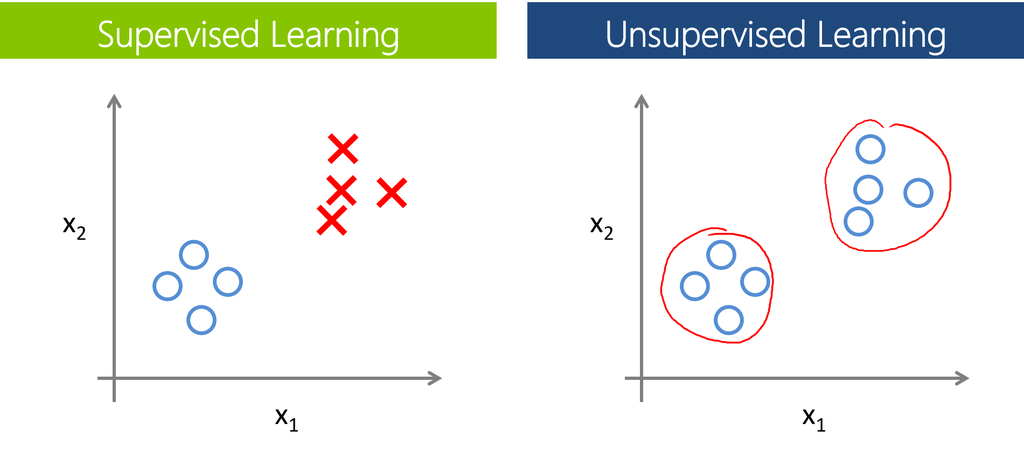

## A simple model: Naive-Bayes Classifier

- “all models are wrong but some models are useful.”
- *naive* assumption: features are independent of each other

$$P(\text{label}\mid\text{feature}) =
\frac{P(\text{feature}\mid
\text{label}) \cdot P(\text{label})}{P(\text{feature})}$$

## Reload our DonorsChoose data

```r
library(tidyverse)
library(quanteda)
library(quanteda.textmodels)
library(tidymodels)
load('data/dfm_donor.Rdata')
dim(dfm_donor)
```

```
[1] 10000  6751
```

We want to predict whether a donation request received funding:

```r
docvars(dfm_donor) |> count(funded)
```

```
  funded    n
1      0 2409
2      1 7591
```

```r
docvars(dfm_donor)$label <- ifelse(docvars(dfm_donor)$funded == 1,
                                    "funded", "not funded")
```

## Training and test sets

- in order to train a model, we need to split our data into training and test sets
- the classifier will learn from the training set. The testset is used to evaluate its performance on unseen data
- there is no optimal solution for the proportions to split train and test data (see [bias-variance tradeoff](https://en.wikipedia.org/wiki/Bias%E2%80%93variance_tradeoff)).

## Training a model

```r
set.seed(1337) # for replication

train <- dfm_sample(dfm_donor, size = 8000) # 80% of the data
test <- dfm_donor[!docnames(dfm_donor) %in% docnames(train), ]

# run the model
donor_nb <- textmodel_nb(x = train, y = docvars(train)$label)
summary(donor_nb)
```

```
Call:
textmodel_nb.dfm(x = train, y = docvars(train)$label)

Class Priors:
(showing first 2 elements)
    funded not funded
       0.5        0.5

Estimated Feature Scores:
             typical      day     room  consists      lot questions    coming
funded     0.0002153 0.003565 0.001304 0.0002072 0.001043 0.0005356 0.0006231
not funded 0.0002450 0.003616 0.001364 0.0001985 0.001052 0.0005111 0.0005618
           interested     minds    brains     like   sponges       age
funded      0.0003701 0.0004791 0.0001669 0.003144 8.478e-05 0.0005988
not funded  0.0003253 0.0004562 0.0001183 0.003096 5.914e-05 0.0006674
             soaking    every       bit information   however     times
funded     1.211e-05 0.001657 1.319e-04   0.0007805 0.0009837 0.0007455
not funded 2.112e-05 0.001745 9.293e-05   0.0008618 0.0010983 0.0008068
             factors  struggle    daily     basis    really  amazing     proud
funded     6.325e-05 0.0006392 0.001572 0.0001561 0.0009016 0.001308 0.0003203
not funded 3.379e-05 0.0007519 0.001533 0.0001436 0.0010054 0.001200 0.0003548
              thirst   located     urban       san
funded     8.882e-05 0.0006796 0.0004535 4.575e-05
not funded 1.098e-04 0.0007055 0.0004393 3.379e-05
```

## Model evaluation: Confusion matrix & accuracy

|  | Reference |  |
| --- | --- | --- |
| **Predicted** | *TRUE* | *FALSE* |
| *TRUE* | True Positives | False Positives |
| *FALSE* | False Negatives | True Negatives |

$$Accuracy = \frac{TP + TN }{TP + FP + FN + TN}$$

## Constructing the confusion matrix

```r
pred_names <- predict(donor_nb, newdata = test)
pred_df <- data.frame(obs = docvars(test)$label,
                      pred = pred_names) |>
  mutate(across(everything(), factor)) |>
  rownames_to_column()

cmat <- conf_mat(pred_df, truth = obs, estimate = pred)
cmat # Confusion Matrix
```

```
            Truth
Prediction   funded not funded
  funded       1026        265
  not funded    505        204
```

## Accuracy

Correct predictions are positioned on the diagonal of the accuracy matrix. Their share of all predictions corresponds to the model accuracy:

```r
sum(diag(cmat$table)) / sum(cmat$table) # Accuracy
```

```
[1] 0.615
```

## Other metrics for performance evaluation

- accuracy is often not a good measure of performance, especially for imbalanced classes
- multiple alternatives are available, e.g. balanced accuracy

$$Sensitivity = \frac{TP}{TP + FN}; Specificity = \frac{TN}{TN + FP}$$
$$Balanced\ Accuracy = \frac{Sensitivity + Specificity}{2}$$

## Evaluating model performance

Using `summary()` on a confusion matrix object calculates multiple evaluation metrics:

```r
summary(cmat)
```

```
# A tibble: 13 × 3
   .metric              .estimator .estimate
   <chr>                <chr>          <dbl>
 1 accuracy             binary        0.615
 2 kap                  binary        0.0893
 3 sens                 binary        0.670
 4 spec                 binary        0.435
 5 ppv                  binary        0.795
 6 npv                  binary        0.288
 7 mcc                  binary        0.0931
 8 j_index              binary        0.105
 9 bal_accuracy         binary        0.553
10 detection_prevalence binary        0.646
11 precision            binary        0.795
12 recall               binary        0.670
13 f_meas               binary        0.727
```

## Cross-validation

- repeat the model training on several train/test splits
- assess performance across all runs
- we’ll use a simple k-fold variant, where k equals the number of splits

```r
cross_val <- function(
            input_dfm, # feature dfm
            label,# variable holding labels
            train_size, # size of training data
            k = 10) # number of runs
{
  runs <- c(1:k) # vector for number of runs
  results_df <- tibble() # empty dataset for results

  for (run in seq_along(runs)) { # loop
    print(str_c("Cross Validation Run: ", as.character(run)))
    set.seed(run) # adjust set for replication purposes

    train <- dfm_sample(input_dfm, size = train_size)
    test <- input_dfm[!docnames(input_dfm) %in% docnames(train),]
    textmodel <- textmodel_nb(train,  docvars(train)[[label]])
    pred <- predict(textmodel, newdata = test)
    pred_df <- tibble(obs = docvars(test)[[label]],
                      pred = pred) |>
      mutate(across(everything(), factor)) |>
      rownames_to_column()
    eval <- conf_mat(pred_df,  truth = obs, estimate = pred)

    # add data to df within loop
    run_df <- summary(eval) |>
      mutate(cv_split = run)
    # add data to df outside of loop
    results_df <- results_df |> bind_rows(run_df)

  }
  return(results_df)
}
```

## Running validation over 10 splits

```r
results_cv <- cross_val(input_dfm = dfm_donor, label = 'label',
                        train_size = 9000, k = 10)
```

```
[1] "Cross Validation Run: 1"
[1] "Cross Validation Run: 2"
[1] "Cross Validation Run: 3"
[1] "Cross Validation Run: 4"
[1] "Cross Validation Run: 5"
[1] "Cross Validation Run: 6"
[1] "Cross Validation Run: 7"
[1] "Cross Validation Run: 8"
[1] "Cross Validation Run: 9"
[1] "Cross Validation Run: 10"
```

```r
head(results_cv)
```

```
# A tibble: 6 × 4
  .metric  .estimator .estimate cv_split
  <chr>    <chr>          <dbl>    <int>
1 accuracy binary         0.596        1
2 kap      binary         0.107        1
3 sens     binary         0.628        1
4 spec     binary         0.5          1
5 ppv      binary         0.789        1
6 npv      binary         0.312        1
```

```r
results_cv |> group_by(.metric) |>
  summarise(average = mean(.estimate))
```

```
# A tibble: 13 × 2
   .metric              average
   <chr>                  <dbl>
 1 accuracy               0.624
 2 bal_accuracy           0.578
 3 detection_prevalence   0.630
 4 f_meas                 0.729
 5 j_index                0.157
 6 kap                    0.132
 7 mcc                    0.139
 8 npv                    0.320
 9 ppv                    0.803
10 precision              0.803
11 recall                 0.668
12 sens                   0.668
13 spec                   0.489
```

## What to do when model performance is bad

- adjust feature space
- adjust model parameters
- try different model(s)
- in our case: think about other factors that might be related to the funding success of donation requests

## Other approaches we didn’t cover

- combining predictions of multiple models (e.g. support vector machines, random forest models)
- optimizing hyperparameters (e.g. distribution assumptions of our naive-bayes model)
- using features beyond bag-of-words (e.g. word embeddings, transformer-based nlp)

## When should you use supervised classification?

- if your goal is the best predictive power, supervised models are reasonable choices
- for many social science applications, supervised models are used to infer labels for a larger dataset from a smaller trainingset, which are then used in downstream tasks
- it might be helpful to compare results with dictionary-based approaches

**Questions?**